# Credit Card Fraud Detection

ByungSun Bae

2018-09-19

## Introduction

- 본 문서에서는 Credit Card Fraud Detection 을 위한 모델을 생성해보도록 하겠습니다.
- 사용할 데이터는 캐글에 있는 [Credit Card Fraud Detection](https://www.kaggle.com/mlg-ulb/creditcardfraud) 데이터로 각 변수들은 Time, Amount, Class(Target 변수)를 제외하고 이미 PCA라는 방법을 거쳐서 생성된 변수들(V1 ~ V28)이기 때문에 변수의 의미자체보단 분석 및 모델링에 촛점을 맞추어서 진행하도록하겠습니다.
- 시나리오는 아래와 같습니다.
  - 신용카드 사기 탐지 모형을 만드는 것이 목적입니다.
  - Target(Class)의 Good, Bad 비율을 살펴보고 imbalancing 하다면, 아래 2가지 방식으로 접근하려 합니다.
    - 1. Under Sampling 후 Classifier 생성 : Good의 비율이 압도적으로 많으면 모델링 시 Good으로만 맞추려는 경향이 생기기 때문에 Good과 Bad의 비율을 어느정도 맞춰주는 작업을 수행합니다.
    - 2. AutoEncoder를 이용한 Anomaly Detection 수행 : Bad 자체를 하나의 이상치로 간주하여 전체 데이터중 이상치를 검출하기위한 작업을 수행합니다.
  - Classifier 생성하기 위해서 각 Features(V1 ~ V28, Amount)와 Target(Class)간 분포를 density plot을 통해 어떤 feature가 Target에 영향을 주는지 간단하게 살펴보려 합니다.
  - Classifier는 정확도가 높게 나올 수 있는 Gradient Boosting Machine을 간단한 모델 하나 만들고 Grid Search를 통한 Hyper parameter 최적화를 하겠습니다.

## 데이터 간단하게 살펴보기

- 모델링을 하기 앞서 기본적으로 데이터를 살펴보는 것은 중요한 작업들중 하나입니다.
- 여기서는 간단하게 데이터의 일부분 및 Target의 비율을 살펴보도록 하겠습니다.

### 패키지 및 데이터 불러오기

```r
library(data.table, quietly = TRUE)
library(tidyverse, quietly = TRUE)
library(DT, quietly = TRUE)
library(h2o, quietly = TRUE)

creditcard_dt <- fread("creditcard.csv")
creditcard_dt[, Class := as.factor(Class)]
dim(creditcard_dt)
```

```
## [1] 284807     31
```

- 31개의 변수와 약 28만개의 데이터가 있습니다.

|  | Time | V1 | V2 | V3 | V4 | V5 | V6 | V7 | V8 | V9 | V10 | V11 | V12 | V13 | V14 | V15 | V16 | V17 | V18 | V19 | V20 | V21 | V22 | V23 | V24 | V25 | V26 | V27 | V28 | … |
| --- | --- | --- | --- | --- | --- | --- | --- | --- | --- | --- | --- | --- | --- | --- | --- | --- | --- | --- | --- | --- | --- | --- | --- | --- | --- | --- | --- | --- | --- | --- |
| 1 | 0 | -1.3598071336738 | -0.0727811733098497 | 2.53634673796914 | 1.37815522427443 | -0.338320769942518 | 0.462387777762292 | 0.239598554061257 | 0.0986979012610507 | 0.363786969611213 | 0.0907941719789316 | -0.551599533260813 | -0.617800855762348 | -0.991389847235408 | -0.311169353699879 | 1.46817697209427 | -0.470400525259478 | 0.207971241929242 | 0.0257905801985591 | 0.403992960255733 | 0.251412098239705 | -0.018306777944153 | 0.277837575558899 | -0.110473910188767 | 0.0669280749146731 | 0.128539358273528 | -0.189114843888824 | 0.133558376740387 | -0.0210530534538215 | … |
| 2 | 0 | 1.19185711131486 | 0.26615071205963 | 0.16648011335321 | 0.448154078460911 | 0.0600176492822243 | -0.0823608088155687 | -0.0788029833323113 | 0.0851016549148104 | -0.255425128109186 | -0.166974414004614 | 1.61272666105479 | 1.06523531137287 | 0.48909501589608 | -0.143772296441519 | 0.635558093258208 | 0.463917041022171 | -0.114804663102346 | -0.183361270123994 | -0.145783041325259 | -0.0690831352230203 | -0.225775248033138 | -0.638671952771851 | 0.101288021253234 | -0.339846475529127 | 0.167170404418143 | 0.125894532368176 | -0.00898309914322813 | 0.0147241691924927 | … |
| 3 | 1 | -1.35835406159823 | -1.34016307473609 | 1.77320934263119 | 0.379779593034328 | -0.503198133318193 | 1.80049938079263 | 0.791460956450422 | 0.247675786588991 | -1.51465432260583 | 0.207642865216696 | 0.624501459424895 | 0.066083685268831 | 0.717292731410831 | -0.165945922763554 | 2.34586494901581 | -2.89008319444231 | 1.10996937869599 | -0.121359313195888 | -2.26185709530414 | 0.524979725224404 | 0.247998153469754 | 0.771679401917229 | 0.909412262347719 | -0.689280956490685 | -0.327641833735251 | -0.139096571514147 | -0.0553527940384261 | -0.0597518405929204 | … |
| 4 | 1 | -0.966271711572087 | -0.185226008082898 | 1.79299333957872 | -0.863291275036453 | -0.0103088796030823 | 1.24720316752486 | 0.23760893977178 | 0.377435874652262 | -1.38702406270197 | -0.0549519224713749 | -0.226487263835401 | 0.178228225877303 | 0.507756869957169 | -0.28792374549456 | -0.631418117709045 | -1.0596472454325 | -0.684092786345479 | 1.96577500349538 | -1.2326219700892 | -0.208037781160366 | -0.108300452035545 | 0.00527359678253453 | -0.190320518742841 | -1.17557533186321 | 0.647376034602038 | -0.221928844458407 | 0.0627228487293033 | 0.0614576285006353 | … |
| 5 | 2 | -1.15823309349523 | 0.877736754848451 | 1.548717846511 | 0.403033933955121 | -0.407193377311653 | 0.0959214624684256 | 0.592940745385545 | -0.270532677192282 | 0.817739308235294 | 0.753074431976354 | -0.822842877946363 | 0.53819555014995 | 1.3458515932154 | -1.11966983471731 | 0.175121130008994 | -0.451449182813529 | -0.237033239362776 | -0.0381947870352842 | 0.803486924960175 | 0.408542360392758 | -0.00943069713232919 | 0.79827849458971 | -0.137458079619063 | 0.141266983824769 | -0.206009587619756 | 0.502292224181569 | 0.219422229513348 | 0.215153147499206 | … |
| 6 | 2 | -0.425965884412454 | 0.960523044882985 | 1.14110934232219 | -0.168252079760302 | 0.42098688077219 | -0.0297275516639742 | 0.476200948720027 | 0.260314333074874 | -0.56867137571251 | -0.371407196834471 | 1.34126198001957 | 0.359893837038039 | -0.358090652573631 | -0.137133700217612 | 0.517616806555742 | 0.401725895589603 | -0.0581328233640131 | 0.0686531494425432 | -0.0331937877876282 | 0.0849676720682049 | -0.208253514656728 | -0.559824796253248 | -0.0263976679795373 | -0.371426583174346 | -0.232793816737034 | 0.105914779097957 | 0.253844224739337 | 0.0810802569229443 | … |
| 7 | 4 | 1.22965763450793 | 0.141003507049326 | 0.0453707735899449 | 1.20261273673594 | 0.191880988597645 | 0.272708122899098 | -0.00515900288250983 | 0.0812129398830894 | 0.464959994783886 | -0.0992543211289237 | -1.41690724314928 | -0.153825826253651 | -0.75106271556262 | 0.16737196252175 | 0.0501435942254188 | -0.443586797916727 | 0.00282051247234708 | -0.61198733994012 | -0.0455750446637976 | -0.21963255278686 | -0.167716265815783 | -0.270709726172363 | -0.154103786809305 | -0.780055415004671 | 0.75013693580659 | -0.257236845917139 | 0.0345074297438413 | 0.00516776890624916 | … |
| 8 | 7 | -0.644269442348146 | 1.41796354547385 | 1.0743803763556 | -0.492199018495015 | 0.948934094764157 | 0.428118462833089 | 1.12063135838353 | -3.80786423873589 | 0.615374730667027 | 1.24937617815176 | -0.619467796121913 | 0.291474353088705 | 1.75796421396042 | -1.32386521970526 | 0.686132504394383 | -0.0761269994382006 | -1.2221273453247 | -0.358221569869078 | 0.324504731321494 | -0.156741852488285 | 1.94346533978412 | -1.01545470979971 | 0.057503529867291 | -0.649709005559993 | -0.415266566234811 | -0.0516342969262494 | -1.20692108094258 | -1.08533918832377 | … |
| 9 | 7 | -0.89428608220282 | 0.286157196276544 | -0.113192212729871 | -0.271526130088604 | 2.6695986595986 | 3.72181806112751 | 0.370145127676916 | 0.851084443200905 | -0.392047586798604 | -0.410430432848439 | -0.705116586646536 | -0.110452261733098 | -0.286253632470583 | 0.0743553603016731 | -0.328783050303565 | -0.210077268148783 | -0.499767968800267 | 0.118764861004217 | 0.57032816746536 | 0.0527356691149697 | -0.0734251001059225 | -0.268091632235551 | -0.204232669947878 | 1.0115918018785 | 0.373204680146282 | -0.384157307702294 | 0.0117473564581996 | 0.14240432992147 | … |
| 10 | 9 | -0.33826175242575 | 1.11959337641566 | 1.04436655157316 | -0.222187276738296 | 0.49936080649727 | -0.24676110061991 | 0.651583206489972 | 0.0695385865186387 | -0.736727316364109 | -0.366845639206541 | 1.01761446783262 | 0.836389570307029 | 1.00684351373408 | -0.443522816876142 | 0.150219101422635 | 0.739452777052119 | -0.540979921943059 | 0.47667726004282 | 0.451772964394125 | 0.203711454727929 | -0.246913936910008 | -0.633752642406113 | -0.12079408408185 | -0.385049925313426 | -0.0697330460416923 | 0.0941988339514961 | 0.246219304619926 | 0.0830756493473326 | … |

### 중복 확인 및 제거

- 데이터중 중복건수가 존재하는지 확인 후 있으면 제거를 하도록 하겠습니다.

```r
creditcard_rm_dup <- creditcard_dt[!duplicated(creditcard_dt[, -"Time"]),]
dim(creditcard_rm_dup)
```

```
## [1] 275663     31
```

- 데이터가 284,807개에서 275,663개로 약 9천개가 줄었습니다.
- 이렇게 중복된 건수가 있는지 반드시 확인을 하신 후 제거를 해주셔야합니다.
- 확인하지않고 그대로 사용하면 Trainig과 Test set으로 데이터를 나눌때 중복되는 데이터가 각각의 set에 나누어져 들어갈수 있습니다.
- 그렇게 되면 제대로된 모형 검증을 수행할 수 없기 때문입니다.

### Target Level 분포

- 0 : **Good**, 1 : **Bad** 를 의미합니다.
- 이들의 비율이 어떤지 확인해보도록 하겠습니다.

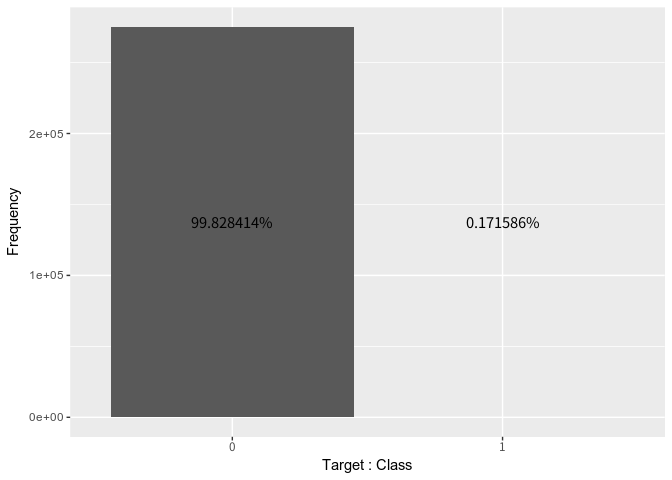

```r
creditcard_rm_dup$Class %>%
  as.vector() %>%
  table(dnn = "Class") %>%
  as.data.frame(.) %>%
  ggplot(data = ., aes(x = as.factor(Class), y = Freq)) +
  geom_bar(stat = "identity") +
  geom_text(aes(label = paste0(round(Freq/sum(Freq), 8) * 100, "%"), y = max(Freq) / 2)) +
  xlab("Target : Class") + ylab("Frequency")
```

- Class 1의 비율이 0.17%으로 매우 낮은 수치입니다.
- imbalanced data이므로 2가지 접근방식을 수행해보도록 하겠습니다.
  - Under Sampling
  - Anomaly Detection

## Under Sampling 및 데이터 탐색

### Under Sampling

- 먼저 Under Sampling을 수행하기에 앞서 개발데이터(training set)와 검증데이터(test set)를 나눈 후 개발데이터에서 Under Sampling을 수행하겠습니다.

> 개발데이터와 검증데이터로 나누기

```r
set.seed(1234)
train_idx <- sample(nrow(creditcard_rm_dup), size = 0.8 * nrow(creditcard_rm_dup), replace = FALSE)
cc_train <- creditcard_dt[train_idx,]
cc_test <- creditcard_dt[-train_idx,]
```

> 개발데이터에서 Target 분포 수치로 확인

```r
good_count <- sum(cc_train$Class == 0)
bad_count <- sum(cc_train$Class == 1)

sprintf(
  "Good 케이스 : %d (%.4f) | Bad 케이스 : %d (%.4f)",
  good_count,
  good_count / nrow(cc_train) * 100,
  bad_count,
  bad_count / nrow(cc_train) * 100
  )
```

```
## [1] "Good 케이스 : 220137 (99.8218) | Bad 케이스 : 393 (0.1782)"
```

> Under Sampling 수행
- 여기서는 Good과 Bad의 비율을 98:2로 맞췄습니다.

```r
good_idx <- sample(which(cc_train$Class == 0), size = bad_count * 49, replace = FALSE)

cc_train_uns <- cc_train[c(good_idx, which(cc_train$Class == 1)),]
dim(cc_train_uns)
```

```
## [1] 19650    31
```

- Under Sampling 후 220137 ==> 19650 으로 모델링에 사용할 데이터 셋이 줄어들었습니다.

### 데이터 탐색

> V1 ~ V28 분포
- V1부터 V28까지 각 변수별로 Class에 대해 어떻게 분포되어있는지 density plot으로 살펴보겠습니다.

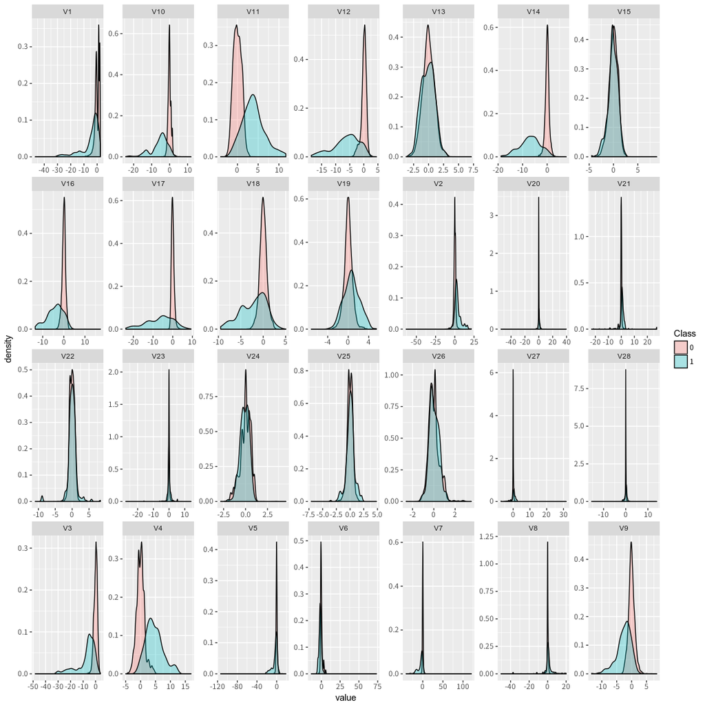

```r
creditcard_g <- gather(cc_train_uns, key = "PCA_key", value = "value", -Time, -Amount, -Class)
creditcard_g <- as.data.table(creditcard_g)
ggplot(creditcard_g, aes(x = value)) + geom_density(aes(fill = Class), alpha = 0.3) +
  facet_wrap(~ PCA_key, nrow = 4, scales = "free")
```

- 각 변수별로 Target값에 대한 그래프를 그려봤습니다.
- x축과 y축의 값은 잠깐 제외하고 그래프를 살펴보면 비슷한 모양의 그래프를 가진 변수들을 휴리스틱하게 묶을 수 있을 것 같습니다.
- 1차적으로는 뾰족하면서 퍼짐정도가 작은 변수들끼리 묶을수 있겠네요.
  - V5, V6, V7, V8, V20, V21, V23, V27, V28
- 2차적으로는 Good, Bad간 그래프가 거의 겹쳐있는 변수들끼리 묶을 수 있겠네요.
  - V13, V15, V22, V24, V25, V26
- 그리고 나머지 변수들을 전부 묶어서 그래프를 보도록 하겠습니다.
  - V1, V2, V3, V4, V9, V10, V11, V12, V14, V16, V17, V18, V19

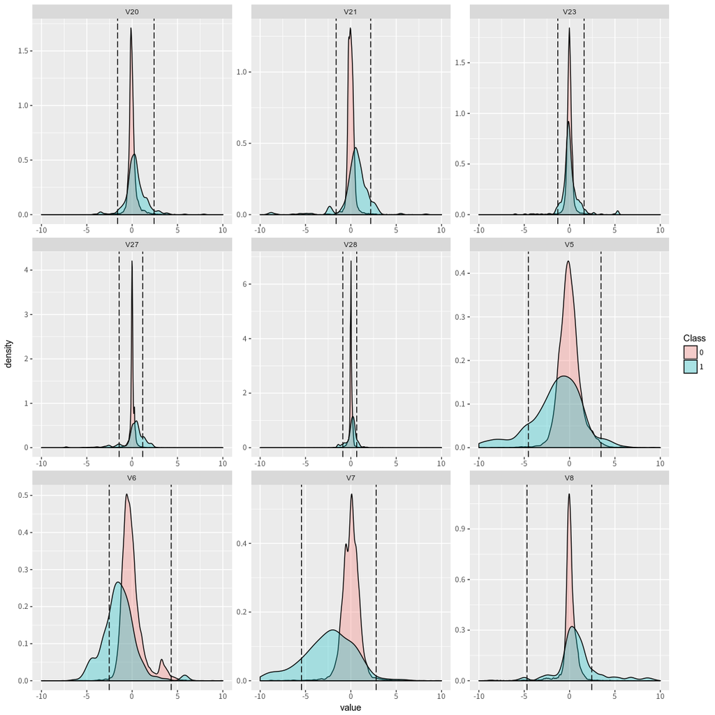

```r
set_1 <- c("V5", "V6", "V7", "V8", "V20", "V21", "V23", "V27", "V28")

creditcard_g[, c("per1", "per99") := list(quantile(value, 0.01),
                           quantile(value, 0.99)), by = "PCA_key"]

creditcard_g[PCA_key %in% set_1,] %>%
  ggplot(., aes(x = value)) + geom_density(aes(fill = Class), alpha = 0.3) +
  geom_vline(aes(xintercept = per1), linetype = "longdash") +
  geom_vline(aes(xintercept = per99), linetype = "longdash") +
  facet_wrap(~ PCA_key, nrow = 4, scales = "free") + xlim(c(-10, 10))
```

- 1차적으로 나눈 변수들을 다시 그래프로 표현했습니다.
  - 하지만 기존에 그렸던 그래프들은 Outlier로 인해 형태를 알아보기 어려웠습니다.
  - 그래서 1%분위수와 99%분위수를 선으로 표현한 후 x축의 범위를 일괄적으로 -10에서 10까지 지정하여 다시 표현했습니다.
  - x축의 범위를 줄인 이유는 각 변수별로 데이터가 어떻게 분포되어있는지 자세히 보기위함이었습니다.
- 대부분의 변수들은 Good(=0)과 Bad(=1)간 그래프가 많이 겹쳐있는 모습을 볼 수 있습니다.
- V6와 V7은 겹치긴했어도 구간화를 수행하면 조금 나아지지않을까하는 생각이 드네요.
  - 하지만 따로 구간화를 수행하진 않겠습니다.

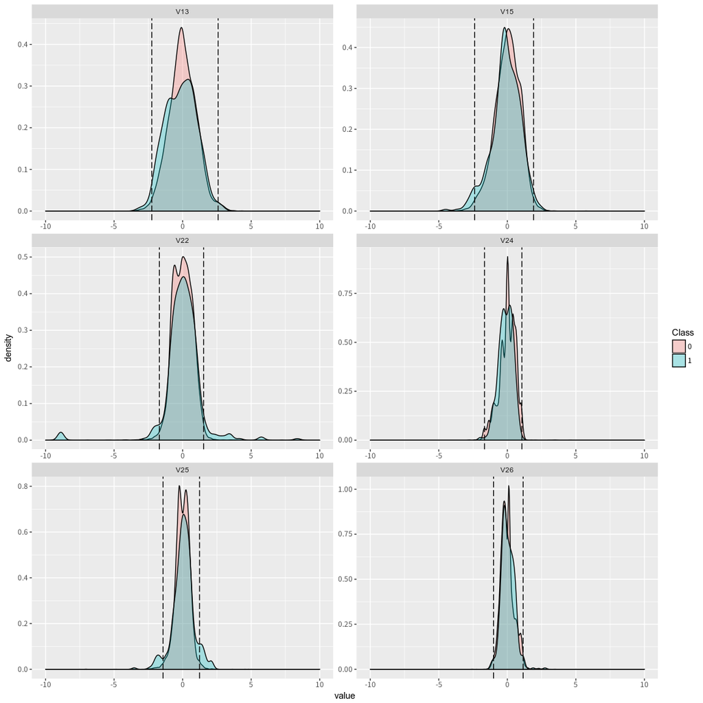

```r
set_2 <- c("V13", "V15", "V22", "V24", "V25", "V26")

creditcard_g %>%
  filter(PCA_key %in% set_2) %>%
  ggplot(., aes(x = value)) + geom_density(aes(fill = Class), alpha = 0.3) +
  geom_vline(aes(xintercept = per1), linetype = "longdash") +
  geom_vline(aes(xintercept = per99), linetype = "longdash") +
  facet_wrap(~ PCA_key, nrow = 4, scales = "free") + xlim(c(-10, 10))
```

- 2차적으로 나눈 변수들도 1차와 같은 방식으로 그래프를 다시 그렸습니다.
- 대부분의 변수들은 Good(=0)과 Bad(=1)간 그래프가 많이 겹쳐있는 모습을 볼 수 있습니다.
- 이러한 변수들은 머신러닝 모형에서 그리 중요한 인자로 추출되진 않을 것 같습니다.

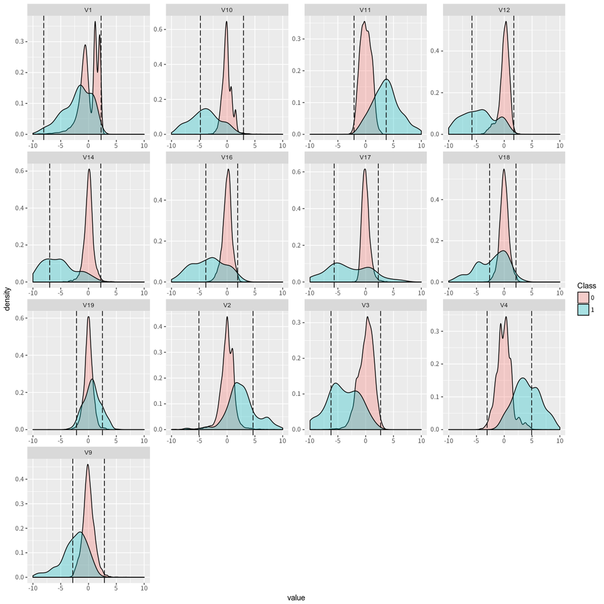

```r
set_3 <- c("V1", "V2", "V3", "V4", "V9", "V10", "V11", "V12", "V14", "V16", "V17", "V18", "V19")

creditcard_g %>%
  filter(PCA_key %in% set_3) %>%
  ggplot(., aes(x = value)) + geom_density(aes(fill = Class), alpha = 0.3) +
  geom_vline(aes(xintercept = per1), linetype = "longdash") +
  geom_vline(aes(xintercept = per99), linetype = "longdash") +
  facet_wrap(~ PCA_key, nrow = 4, scales = "free") + xlim(c(-10, 10))
```

- 나머지 변수들도 1차, 2차와 같은 방식으로 그래프를 다시 그렸습니다.
- V19를 제외한 변수들은 Good(=0)과 Bad(=1)를 잘 나누는 것처럼 보이기합니다.
- V19는 머신러닝 모형에서 그다지 중요하지 않은 인자로 추출될 것 같아보입니다.
- V9은 1차의 V6와 V7과 마찬가지로 구간화를 하면 Target을 잘 분류하는 인자로 바꿀수 있을 것 같지만 구간화를 수행하진 않겠습니다.

> Amount 분포

```r
cc_train_uns[, summary(Amount)]
```

```
##      Min.   1st Qu.    Median      Mean   3rd Qu.      Max.
##     0.000     5.742    22.475    95.936    79.950 25691.160
```

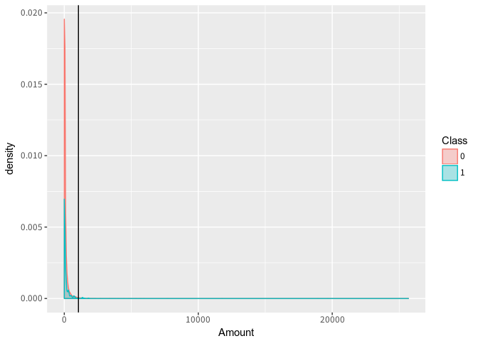

```r
cc_train_uns %>%
  ggplot(aes(x = Amount)) +
  geom_density(aes(fill = Class, colour = Class), alpha = 0.3) +
  geom_vline(xintercept = quantile(cc_train_uns$Amount, 0.99))
```

- Amount의 경우 꼬리를 기준으로 오른쪽으로 치우쳐져 있습니다.
- 검정색 선은 Amount의 99퍼센트 분위수 입니다.
- 그런데 위와 같이 오른쪽으로 꼬리가 긴 분포의 경우 살펴보기가 너무 힘듭니다.
- 먼저 검정색 선까지만 density plot을 그려보겠습니다.

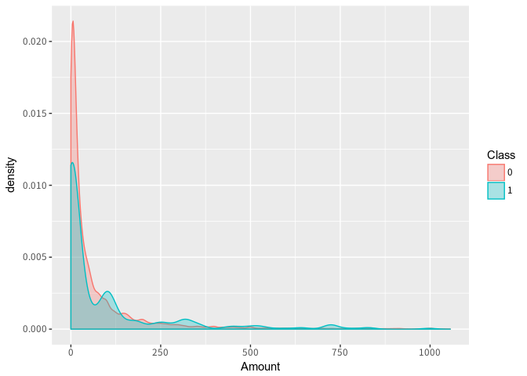

```r
cc_train_uns %>%
  ggplot(aes(x = Amount)) +
  geom_density(aes(fill = Class, colour = Class), alpha = 0.3) +
  xlim(c(quantile(cc_train_uns$Amount, c(0, 0.99))))
```

- 그래프를 봤을 때, Class가 0일 때 분포와 1일 때 분포가 그리 많이 차이나지 않는 것 같습니다.
- 대체로 두 집단간 차이가 없어보이지만 이 그림 하나로는 설명이 부족합니다.
- 그래서 Boxplot을 하나 더 시각화해서 Class간 Amount 분포 차이가 있는지 살펴보겠습니다.

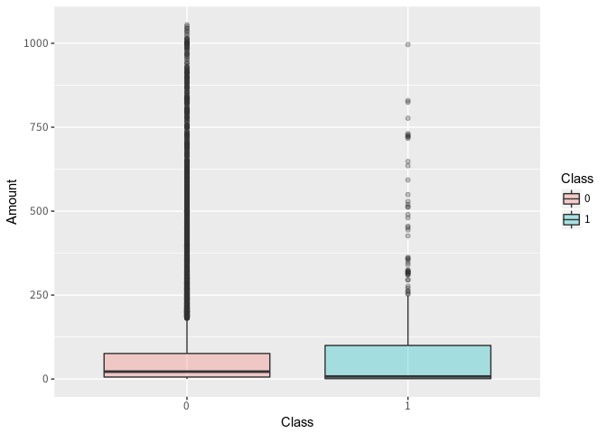

```r
cc_train_uns %>%
  ggplot(aes(x = Class, y = Amount)) +
  geom_boxplot(aes(fill = Class), alpha = 0.3) +
  ylim(c(quantile(cc_train_uns$Amount, c(0, 0.99))))
```

- 위처럼 Boxplot이 그려지는 이유는 Outlier에 해당하는 데이터가 많기 때문입니다.
- 그래서 여전히 분포간 차이가 있는지 보기가 쉽지않습니다.
- 때문에 log변환을 수행 후 다시 시각화를 하였습니다.
- 단, Amount의 최솟값중 0이 포함되어있기 때문에 1을 더한 후 log변환을 수행했습니다.

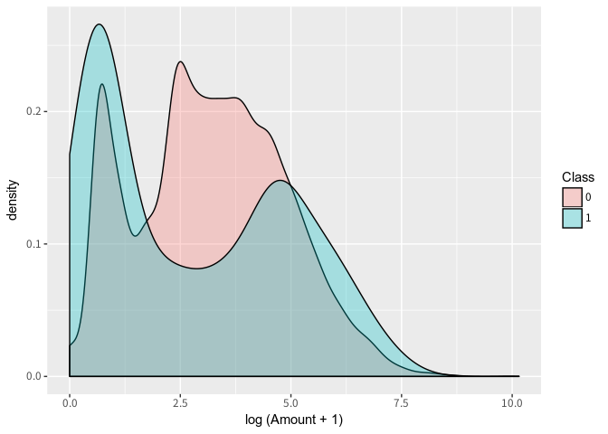

```r
cc_train_uns %>%
  ggplot(aes(x = log(Amount + 1))) +
  geom_density(aes(fill = Class), alpha = 0.3) +
  xlab("log (Amount + 1)")
```

- x축에서 대략 1.5 ~ 2.5사이 값에서 5.0 값사이에는 Class가 0인 데이터가 더 많다는 걸 볼 수 있습니다.

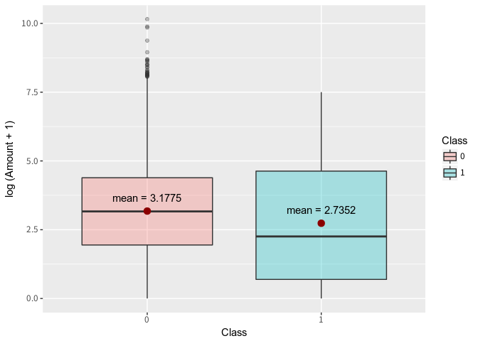

```r
mean_fun <- function(x) data.frame(y = mean(x), label = paste0("mean = ", round(mean(x), 4)))

cc_train_uns %>%
  ggplot(aes(x = Class, y = log(Amount + 1))) +
  geom_boxplot(aes(fill = Class), alpha = 0.3) +
  stat_summary(fun.y = mean, geom = "point", colour = "darkred", size = 3) +
  stat_summary(fun.data = mean_fun, geom = "text", vjust = -1.2) +
  ylab("log (Amount + 1)")
```

- 각 Class 별 Box를 보면 중간에 검정색 실선이 하나 그려져 있는데 이는 중앙값이라고 해서 50퍼센트 분위수를 가리킵니다.
- Box의 테두리중 수평선 2개가 있는데 각각 25퍼센트 분위수와 75퍼센트 분위수를 가리킵니다.
- 그리고 평균값은 어두운 빨간색점과 텍스트로 표시하였습니다.
- Box의 크기는 Class가 0일때보다 1일때 더 크며, 평균값과 중앙값은 둘다 Class가 1일때가 0일때보다 더 작습니다.
- Class가 0일때 사분위수 범위가 1일때 사분위수 범위에 포함되며 density plot과 함께 살펴보면 log(Amount + 1)이 Class에 어느정도 영향을 줄 거라고 예상할 수 있습니다.
- 나중에 모델링을 수행하면서 Amount를 넣었을 때 모형과 log(Amount + 1)를 넣었을때 모형중 어느것이 더 좋은지 확인해보도록 하겠습니다.

```r
cc_train[, log_amount_1 := log(Amount + 1)]
cc_train_uns[, log_amount_1 := log(Amount + 1)]
cc_test[, log_amount_1 := log(Amount + 1)]
```

### 탐색 후 summary

- V1 ~ V28, 그리고 Amount의 분포를 살펴봤습니다.
- Target에 영향을 줄 것 같지 않을 변수들을 살펴보고, 그 중 3가지의 변수는 구간화를 통해 더 나은 인자가 될 것 같습니다.
  - V6, V7 그리고 V9
- 그런데 구간화를 수행하지 않겠다고 이야기 했습니다.
- 그 이유는 저희가 이번에 사용할 모형은 RandomForest와 Gradient Boosting Machine인데 이미 Tree-Based 모형이라서 내부적으로 알아서 구간화를 수행하기 때문입니다.
- 그리고 Amount의 경우 log(Amount + 1)를 수행하여 Amount를 넣었을 때와 log(Amount + 1)를 넣었을때 모형에서 변수중요도가 어떻게 추출되는지 확인해볼 것 입니다.

### Classifier 생성

- `h2o` 패키지를 이용하여 Gradient Boosting Machine(GBM) 모델을 하나 생성해보도록 하겠습니다.

> R과 h2o 연결

```r
h2o.init(nthreads = -1)
```

```
##
## H2O is not running yet, starting it now...
##
## Note:  In case of errors look at the following log files:
##     /tmp/RtmpH8e8yW/h2o_spark_started_from_r.out
##     /tmp/RtmpH8e8yW/h2o_spark_started_from_r.err
##
##
## Starting H2O JVM and connecting: . Connection successful!
##
## R is connected to the H2O cluster:
##     H2O cluster uptime:         3 seconds 553 milliseconds
##     H2O cluster timezone:       Asia/Seoul
##     H2O data parsing timezone:  UTC
##     H2O cluster version:        3.20.0.2
##     H2O cluster version age:    3 months and 3 days
##     H2O cluster name:           H2O_started_from_R_spark_hvq522
##     H2O cluster total nodes:    1
##     H2O cluster total memory:   1.93 GB
##     H2O cluster total cores:    4
##     H2O cluster allowed cores:  4
##     H2O cluster healthy:        TRUE
##     H2O Connection ip:          localhost
##     H2O Connection port:        54321
##     H2O Connection proxy:       NA
##     H2O Internal Security:      FALSE
##     H2O API Extensions:         XGBoost, Algos, AutoML, Core V3, Core V4
##     R Version:                  R version 3.4.4 (2018-03-15)
```

- 위 메세지에서 “Connection successful!”이라는 메세지가 뜨면 `h2o`와 `R`이 잘 연결됐다는 의미입니다.

> 모델 생성시 필요한 feature와 target 지정

```r
target <- "Class"
features <- names(cc_train_uns)[! names(cc_train_uns) %in% c(target, "Time")]
```

> h2o 엔진활용을 위한 오브젝트 변환

```r
cc_train_uns_h2o <- as.h2o(cc_train_uns, destination_frame = "cc_train_uns_h2o")
cc_test_h2o <- as.h2o(cc_test, destination_frame = "cc_test_h2o")
```

> GBM 모델 생성

```r
model <-
    h2o.gbm(
    x = features,
    y = target,
    training_frame = cc_train_uns_h2o,
    model_id = "simple_gbm",
    nfolds = 5,
    keep_cross_validation_predictions = TRUE,
    fold_assignment = "Modulo"
    )
```

- 간단한 GBM 모델을 만들었습니다.
- Gradient Boosting Machine에서 Boosting이란 앙상블 기법의 일종이며, weak learner들의 앙상블모형이라 보시면 되겠습니다.
  - 쉽게 말씀드리자면, base learner가 training set을 이용하여 학습 후 처음 base learner의 예측값과 실제값사이의 residuals를 구합니다.
  - 이 residuals을 Target으로, 기존 base learner를 학습시킬때 사용했던 features들을 이용하여 weak learner를 학습시킵니다.
  - 새로운 base learner는 기존 base learner + weak learner 입니다.
  - 이러한 과정을 반복적으로 수행합니다.
  - 그러면 결국 생성되는 base learner는 맨처음 만든 base learner + 여러개의 weak learner들이 됩니다.
- weak learner는 Tree 모형이 될 수 있고 선형 모형이 될 수도 있습니다.
- Boosting도 여러가지 알고리즘들이 존재하며, 저는 그 중 Gradient Boosting Machine을 사용했습니다.
- 기본적으로 `h2o`에서는 weak learner가 Tree 모형이며, GBM말고도 Xgboost도 존재합니다.
- LightGBM은 따로 구현되어있진 않고 Xgboost를 사용할 때 options을 바꾸면 LightGBM을 모방할 수 있습니다.
- Boosting에 대해서 자세히 알고 싶다면 Boosting을 살펴보세요.

> GBM 모델 결과 확인
- 위에서 수행했던 GBM의 Hyper parameter 셋팅은 아래처럼 확인을 하실 수 있습니다.
- 그리고 5-folds cross-validation을 수행하였습니다.

```r
summary(model)
```

```
## Model Details:
## ==============
##
## H2OBinomialModel: gbm
## Model Key:  simple_gbm
## Model Summary:
##   number_of_trees number_of_internal_trees model_size_in_bytes min_depth
## 1              50                       50               14889         5
##   max_depth mean_depth min_leaves max_leaves mean_leaves
## 1         5    5.00000         13         29    18.72000
##
## H2OBinomialMetrics: gbm
## ** Reported on training data. **
##
## MSE:  0.001311067
## RMSE:  0.03620866
## LogLoss:  0.00681218
## Mean Per-Class Error:  0.02682142
## AUC:  0.9988753
## Gini:  0.9977505
##
## Confusion Matrix (vertical: actual; across: predicted) for F1-optimal threshold:
##            0   1    Error       Rate
## 0      19253   4 0.000208   =4/19257
## 1         21 372 0.053435    =21/393
## Totals 19274 376 0.001272  =25/19650
##
## Maximum Metrics: Maximum metrics at their respective thresholds
##                         metric threshold    value idx
## 1                       max f1  0.296462 0.967490 126
## 2                       max f2  0.143206 0.961343 142
## 3                 max f0point5  0.456034 0.985460 117
## 4                 max accuracy  0.296462 0.998728 126
## 5                max precision  0.999839 1.000000   0
## 6                   max recall  0.002077 1.000000 356
## 7              max specificity  0.999839 1.000000   0
## 8             max absolute_mcc  0.296462 0.967088 126
## 9   max min_per_class_accuracy  0.017851 0.984733 239
## 10 max mean_per_class_accuracy  0.017851 0.987875 239
##
```

[output cut: 142 more lines]

```
##   variable relative_importance scaled_importance percentage
## 1      V14          406.699646          1.000000   0.733439
## 2      V17           38.142807          0.093786   0.068786
## 3      V10           27.373390          0.067306   0.049365
## 4       V4           10.658332          0.026207   0.019221
## 5      V18           10.613290          0.026096   0.019140
##
## ---
##    variable relative_importance scaled_importance percentage
## 25      V25            0.992014          0.002439   0.001789
## 26       V9            0.974437          0.002396   0.001757
## 27      V24            0.304061          0.000748   0.000548
## 28       V5            0.250147          0.000615   0.000451
## 29      V23            0.229030          0.000563   0.000413
## 30       V2            0.152406          0.000375   0.000275
```

> Test set으로 성능 측정

```r
h2o.performance(model, newdata = cc_test_h2o)
```

```
## H2OBinomialMetrics: gbm
##
## MSE:  0.001084872
## RMSE:  0.0329374
## LogLoss:  0.006157825
## Mean Per-Class Error:  0.1061619
## AUC:  0.9719588
## Gini:  0.9439177
##
## Confusion Matrix (vertical: actual; across: predicted) for F1-optimal threshold:
##            0  1    Error       Rate
## 0      64165 13 0.000203  =13/64178
## 1         21 78 0.212121     =21/99
## Totals 64186 91 0.000529  =34/64277
##
## Maximum Metrics: Maximum metrics at their respective thresholds
##                         metric threshold    value idx
## 1                       max f1  0.976194 0.821053  23
## 2                       max f2  0.922455 0.813253  33
## 3                 max f0point5  0.976194 0.842333  23
## 4                 max accuracy  0.976194 0.999471  23
## 5                max precision  0.998235 1.000000   0
## 6                   max recall  0.000823 1.000000 395
## 7              max specificity  0.998235 1.000000   0
## 8             max absolute_mcc  0.976194 0.821519  23
## 9   max min_per_class_accuracy  0.005321 0.929293 330
## 10 max mean_per_class_accuracy  0.005321 0.941103 330
##
## Gains/Lift Table: Extract with `h2o.gainsLift(<model>, <data>)` or `h2o.gainsLift(<model>, valid=<T/F>, xval=<T/F>)`
```

```r
sprintf("검증데이터 셋의 AUC : %.5f", h2o.auc(h2o.performance(model, newdata = cc_test_h2o)))
```

```
## [1] "검증데이터 셋의 AUC : 0.97196"
```

> Grid Search를 통한 최적의 Hyperparameter set 찾아보기
- 하지만 이 모델이 최적화된 모델은 아니겠죠?
- 성능개선을 위해 Grid Search를 통해 나름대로 GBM의 최적의 Hyper parameter set을 찾아보도록 하겠습니다.

```r
grid_id <- "gbm_grid"

hyper_params <- list(
  ntrees = c(50, 100, 150, 200, 300),
  max_depth = c(4, 5, 6, 7),
  col_sample_rate = c(1, 0.8, 0.6)
)

search_criteria <- list(
  strategy = "RandomDiscrete", max_models = 5
)
```

- 실험하고자하는 Hyperparameter 값들을 위와 같이 셋팅합니다.
- 시간이 조금 오래 걸려서 최대 만드는 모델은 5개로 제한하였습니다.

```r
gbm_grid <-
  h2o.grid(
  x = features,
  y = target,
  algorithm = "gbm",
  training_frame = cc_train_uns_h2o,
  grid_id = grid_id,
  hyper_params = hyper_params,
  search_criteria = search_criteria,
  nfolds = 5,
  keep_cross_validation_predictions = TRUE,
  fold_assignment = "Modulo"
  )
```

- AUC를 기준으로 정렬 후 비교적 AUC가 높은 모델을 뽑았습니다.

```r
gbm_grid_auc <- h2o.getGrid(grid_id, sort_by = "auc", decreasing = TRUE)
summary(gbm_grid_auc)
```

```
## H2O Grid Details
## ================
##
## Grid ID: gbm_grid
## Used hyper parameters:
##   -  col_sample_rate
##   -  max_depth
##   -  ntrees
## Number of models: 5
## Number of failed models: 0
##
## Hyper-Parameter Search Summary: ordered by decreasing auc
##   col_sample_rate max_depth ntrees        model_ids                auc
## 1             1.0         4    200 gbm_grid_model_2 0.9793816755573895
## 2             0.6         4    100 gbm_grid_model_1 0.9770046938418745
## 3             0.6         6    200 gbm_grid_model_3 0.9757335523607885
## 4             1.0         7     50 gbm_grid_model_0 0.9745414277825809
## 5             0.8         6    300 gbm_grid_model_4 0.9736048528534814
## H2O Grid Summary
## ================
##
## Grid ID: gbm_grid
## Used hyper parameters:
##   -  col_sample_rate
##   -  max_depth
##   -  ntrees
## Number of models: 5
##   -  gbm_grid_model_2
##   -  gbm_grid_model_1
##   -  gbm_grid_model_3
##   -  gbm_grid_model_0
##   -  gbm_grid_model_4
##
## Number of failed models: 0
```

```r
gbm_best <- h2o.getModel(gbm_grid_auc@model_ids[[1]])
sprintf("검증데이터 셋의 AUC : %.5f", h2o.auc(h2o.performance(gbm_best, newdata = cc_test_h2o)))
```

```
## [1] "검증데이터 셋의 AUC : 0.98149"
```

> 변수 중요도 확인

```r
varimp_dt <- as.data.table(h2o.varimp(gbm_best))
varimp_dt[, rank := 1:nrow(varimp_dt)]
varimp_dt[, c("rank", "variable"), with = FALSE]
```

```
##     rank     variable
##  1:    1          V14
##  2:    2          V17
##  3:    3          V10
##  4:    4          V25
##  5:    5           V4
##  6:    6           V7
##  7:    7          V19
##  8:    8          V26
##  9:    9          V27
## 10:   10          V12
## 11:   11          V11
## 12:   12          V13
## 13:   13          V18
## 14:   14          V21
```

[output cut: 17 more lines]

- 변수 중요도를 한번 살펴보도록 하겠습니다.
- 탐색 당시 몇몇 변수들은 중요도에서도 상위랭크를 차지하지 못할 거라고 이야기 했었는데 그러한 경우도 있고 아닌 경우도 있네요.
- 특히, V26은 정말 의외의 결과였습니다.
- 그래프를 봤을땐 Good과 Bad를 잘 나누지 못했는데 중요한 변수들중 Top 10에 드는군요.
- 그리고 log(Amount + 1)이 Amount에 비해서 더 중요한 변수로 인식됐습니다.

> 모델저장
- 가장 좋은 모델을 선별했다고 가정하고 이 모델을 저장해봅시다.

```r
h2o.saveModel(gbm_best, "gbm_best", force=TRUE)
```

```
## [1] "/home/spark/hard/project/ml_h2o_in_R/gbm_best/gbm_grid_model_2"
```

- 이렇게 모델을 저장해두면 h2o의 버전이 다르지 않는 이상 다른 PC에서도 해당 모델을 사용하실 수 있습니다.

## Anomaly Detection

- 이번에는 Deep Learning 모델중 AutoEncoder를 이용해서 Anomaly Detection을 수행해봅시다.
- Bad 케이스가 상당히 적은 상황에서 Bad를 하나의 이상치로 보고 이상치를 검출하는 작업을 하는 것입니다.
- 그러기 위해서 먼저 AutoEncoder모델을 만들어야 합니다.
- tensorflow나 Keras도 있지만, 저는 이번에도 h2o를 이용하였습니다.
- 이상치 검출 모델을 만든다는 의미는 Good에 해당하는 데이터를 만드는 모형을 하나 만들고, 그 모형에 Good, Bad 케이스를 넣으면, Good의 경우에는 원래 데이터에 가깝게 잘 만들어내지만, Bad의 경우 원래 데이터와 동떨어지게 만들어집니다.
- 그렇게 만들어진 데이터와 원래 데이터간의 Mean Square Error를 계산하면 Good에 비해서 Bad의 경우가 Error가 커지게됩니다.
- 이때 Error에 threshold를 지정해서 Good과 Bad를 나눌 수 있습니다.
- 다행히도 현재 가지고 있는 데이터가 전부 연속형 변수들이기 때문에 이 방법을 사용할 수 있습니다.
- 그리고 위에서 얻은 Classifier의 variable importance를 이용해서 중요한 변수 Top10에 대해서도 Anomaly Detection을 수행해보도록 하겠습니다.

### AutoEncoder 모델 생성

- 먼저 Good에 해당하는 데이터를 선별 후 모델을 생성하겠습니다.

> Good에 해당하는 데이터 선택

```r
cc_train_good_h2o <- as.h2o(cc_train[Class == 0,], destination_frame = "cc_train_good_h2o")
```

> Autoencoder를 위한 모델 생성

```r
autoencoder <-
  h2o.deeplearning(
  x = features,
  training_frame = cc_train_good_h2o,
  model_id = "autoencoder",
  activation = "Tanh",
  hidden = c(15, 15),
  epochs = 50,
  autoencoder = TRUE
  )
```

> anomaly detection을 위한 reconstruction error 생성

```r
cc_anon <- h2o.anomaly(autoencoder, data = cc_test_h2o)
head(cc_anon)
```

```
##   Reconstruction.MSE
## 1       1.706222e-04
## 2       3.229041e-05
## 3       3.301012e-05
## 4       4.404968e-05
## 5       3.262356e-05
## 6       5.207023e-05
```

> reconstruction error에 Target값 맵핑 및 시각화

```r
reconstruct_dt <- cbind(as.data.table(cc_anon), Class = as.factor(as.vector(cc_test_h2o$Class)))
head(reconstruct_dt)
```

```
##    Reconstruction.MSE Class
## 1:       1.706222e-04     0
## 2:       3.229041e-05     0
## 3:       3.301012e-05     0
## 4:       4.404968e-05     0
## 5:       3.262356e-05     0
## 6:       5.207023e-05     0
```

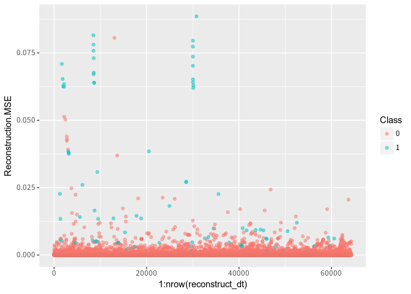

```r
ggplot(reconstruct_dt, aes(x = 1:nrow(reconstruct_dt), y = Reconstruction.MSE)) +
  geom_point(aes(colour = Class), alpha = 0.5)
```

```r
reconstruct_dt[, c("pred_25", "pred_50", "pred_Mean", "pred_75", "pred_85", "pred_95", "pred_99", "pred_99.5") := list(
  as.factor(ifelse(Reconstruction.MSE > quantile(Reconstruction.MSE, probs = 0.25), 1, 0)),
  as.factor(ifelse(Reconstruction.MSE > median(Reconstruction.MSE), 1, 0)),
  as.factor(ifelse(Reconstruction.MSE > mean(Reconstruction.MSE), 1, 0)),
  as.factor(ifelse(Reconstruction.MSE > quantile(Reconstruction.MSE, probs = 0.75), 1, 0)),
  as.factor(ifelse(Reconstruction.MSE > quantile(Reconstruction.MSE, probs = 0.85), 1, 0)),
  as.factor(ifelse(Reconstruction.MSE > quantile(Reconstruction.MSE, probs = 0.95), 1, 0)),
  as.factor(ifelse(Reconstruction.MSE > quantile(Reconstruction.MSE, probs = 0.99), 1, 0)),
  as.factor(ifelse(Reconstruction.MSE > quantile(Reconstruction.MSE, probs = 0.995), 1, 0))
)]

reconstruct_dt[, table(Class, pred_25)]
```

```
##      pred_25
## Class     0     1
##     0 16069 48109
##     1     1    98
```

```r
reconstruct_dt[, table(Class, pred_50)]
```

```
##      pred_50
## Class     0     1
##     0 32134 32044
##     1     5    94
```

```r
reconstruct_dt[, table(Class, pred_Mean)]
```

```
##      pred_Mean
## Class     0     1
##     0 55943  8235
##     1     9    90
```

```r
reconstruct_dt[, table(Class, pred_75)]
```

```
##      pred_75
## Class     0     1
##     0 48200 15978
##     1     8    91
```

```r
reconstruct_dt[, table(Class, pred_85)]
```

```
##      pred_85
## Class     0     1
##     0 54626  9552
##     1     9    90
```

```r
reconstruct_dt[, table(Class, pred_95)]
```

```
##      pred_95
## Class     0     1
##     0 61050  3128
##     1    13    86
```

```r
reconstruct_dt[, table(Class, pred_99)]
```

```
##      pred_99
## Class     0     1
##     0 63613   565
##     1    21    78
```

```r
reconstruct_dt[, table(Class, pred_99.5)]
```

```
##      pred_99.5
## Class     0     1
##     0 63925   253
##     1    30    69
```

- threshold를 Error의 분위수 및 평균값으로 바꿔가면서 Confusion Matrix를 그려봤지만 GBM의 Classifier보단 성능이 별로 좋지않습니다.
- 위 그래프에서도 살펴봤을 때 Class가 Bad(== 1)일때보다 Good(== 0)인 경우 Error가 큰 데이터도 있습니다.
- 이는 AutoEncoder 모델에 의해 생성된 데이터들 중 몇몇 변수를 잘 생성하지 못해서 그럴 수도 있습니다.

> Best GBM의 Top 10 변수를 이용한 AutoEncoder
- 이번에는 위에서 Best GBM model에 의해 선택된 Top 10 변수만 가지고 AutoEncoder를 수행해보겠습니다.

```r
autoencoder_top10 <-
  h2o.deeplearning(
  x = varimp_dt[, variable[1:10]],
  training_frame = cc_train_good_h2o,
  model_id = "autoencoder_top10",
  activation = "Tanh",
  hidden = c(5, 5),
  epochs = 50,
  autoencoder = TRUE
  )
```

```r
cc_anon <- h2o.anomaly(autoencoder_top10, data = cc_test_h2o)
```

```r
reconstruct_dt <- cbind(as.data.table(cc_anon), Class = as.factor(as.vector(cc_test_h2o$Class)))
```

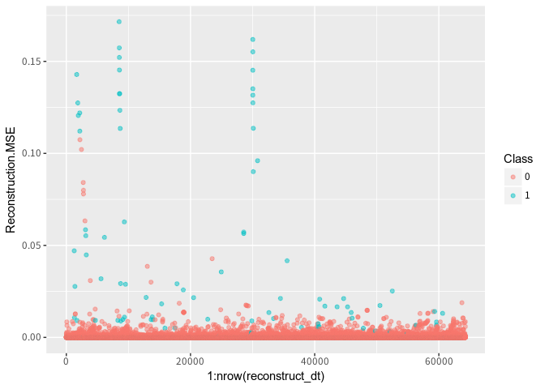

```r
ggplot(reconstruct_dt, aes(x = 1:nrow(reconstruct_dt), y = Reconstruction.MSE)) +
  geom_point(aes(colour = Class), alpha = 0.5)
```

```r
reconstruct_dt[, c("pred_25", "pred_50", "pred_Mean", "pred_75", "pred_85", "pred_95", "pred_99", "pred_99.5") := list(
  as.factor(ifelse(Reconstruction.MSE > quantile(Reconstruction.MSE, probs = 0.25), 1, 0)),
  as.factor(ifelse(Reconstruction.MSE > median(Reconstruction.MSE), 1, 0)),
  as.factor(ifelse(Reconstruction.MSE > mean(Reconstruction.MSE), 1, 0)),
  as.factor(ifelse(Reconstruction.MSE > quantile(Reconstruction.MSE, probs = 0.75), 1, 0)),
  as.factor(ifelse(Reconstruction.MSE > quantile(Reconstruction.MSE, probs = 0.85), 1, 0)),
  as.factor(ifelse(Reconstruction.MSE > quantile(Reconstruction.MSE, probs = 0.95), 1, 0)),
  as.factor(ifelse(Reconstruction.MSE > quantile(Reconstruction.MSE, probs = 0.99), 1, 0)),
  as.factor(ifelse(Reconstruction.MSE > quantile(Reconstruction.MSE, probs = 0.995), 1, 0))
)]

reconstruct_dt[, table(Class, pred_25)]
```

```
##      pred_25
## Class     0     1
##     0 16066 48112
##     1     4    95
```

```r
reconstruct_dt[, table(Class, pred_50)]
```

```
##      pred_50
## Class     0     1
##     0 32132 32046
##     1     7    92
```

```r
reconstruct_dt[, table(Class, pred_Mean)]
```

```
##      pred_Mean
## Class     0     1
##     0 53258 10920
##     1    13    86
```

```r
reconstruct_dt[, table(Class, pred_75)]
```

```
##      pred_75
## Class     0     1
##     0 48198 15980
##     1    10    89
```

```r
reconstruct_dt[, table(Class, pred_85)]
```

```
##      pred_85
## Class     0     1
##     0 54621  9557
##     1    14    85
```

```r
reconstruct_dt[, table(Class, pred_95)]
```

```
##      pred_95
## Class     0     1
##     0 61048  3130
##     1    15    84
```

```r
reconstruct_dt[, table(Class, pred_99)]
```

```
##      pred_99
## Class     0     1
##     0 63615   563
##     1    19    80
```

```r
reconstruct_dt[, table(Class, pred_99.5)]
```

```
##      pred_99.5
## Class     0     1
##     0 63933   245
##     1    22    77
```

- 중요한 변수 10개만 가지고 해도 전체 변수로 AutoEncoder 모델의 성능과 크게 차이는 없습니다.
- 다만, Classifier보다 괜찮은 성능을 보이진 않는 것 같습니다

```r
h2o.confusionMatrix(h2o.performance(gbm_best, newdata = cc_test_h2o))
```

```
## Confusion Matrix (vertical: actual; across: predicted)  for max f1 @ threshold = 0.971762186928404:
##            0  1    Error       Rate
## 0      64166 12 0.000187  =12/64178
## 1         20 79 0.202020     =20/99
## Totals 64186 91 0.000498  =32/64277
```

- 따라서, 2가지 접근 방법중 Under Sampling 후 Classifier를 만드는 것이 비교적 괜찮은 방법이라고 볼 수 있습니다.
- 이번에는 Classifier를 GBM 뿐만 아니라 Random Forest와 Deep Learning 모델을 더 만들어서 모델 비교를 한번 해보도록 하겠습니다.

## 다양한 모델 생성 및 비교

- GBM의 모델 특성상 학습중 계산되는 residuals에 가중치를 둬서 학습을 하기 때문에 정확도가 높게 나오는 경우가 있습니다.
- 그렇다고 항상 RandomForest와 Deep Learning보다 나은 것은 아닙니다.
- 이번에는 RandomForest와 Deep learning 모델을 만들고 비교해보겠습니다.
- 또한, 만들어진 모델들을 이용하여 앙상블 모델을 만들어 보도록 하겠습니다.

> Random Forest grid search
- 기본 Hyperparameter값을 포함해서 Random Forest Grid Search를 해보도록 하겠습니다.

```r
grid_id <- "rf_grid"

hyper_params <- list(
  ntrees = c(50, 100, 150, 200, 300, 400),
  max_depth = c(16, 18, 20, 22, 24),
  sample_rate = c(0.8, 0.6320000291, 0.4)
)

search_criteria <- list(
  strategy = "RandomDiscrete", max_models = 5
)
```

```r
rf_grid <-
  h2o.grid(
  x = features,
  y = target,
  algorithm = "randomForest",
  grid_id = grid_id,
  training_frame = cc_train_uns_h2o,
  hyper_params = hyper_params,
  search_criteria = search_criteria,
  nfolds = 5,
  keep_cross_validation_predictions = TRUE,
  fold_assignment = "Modulo"
  )
```

```r
rf_grid_auc <- h2o.getGrid(grid_id, sort_by = "auc", decreasing = TRUE)
summary(rf_grid_auc)
```

```
## H2O Grid Details
## ================
##
## Grid ID: rf_grid
## Used hyper parameters:
##   -  max_depth
##   -  ntrees
##   -  sample_rate
## Number of models: 5
## Number of failed models: 0
##
## Hyper-Parameter Search Summary: ordered by decreasing auc
##   max_depth ntrees sample_rate       model_ids                auc
## 1        18    300         0.8 rf_grid_model_0 0.9830193600661523
## 2        18    200         0.4 rf_grid_model_2 0.9797686998191464
## 3        24    400         0.4 rf_grid_model_4 0.9766688059369971
## 4        24    200         0.4 rf_grid_model_1 0.9736665600334883
## 5        24    100         0.4 rf_grid_model_3 0.9696855880436591
## H2O Grid Summary
## ================
##
## Grid ID: rf_grid
## Used hyper parameters:
##   -  max_depth
##   -  ntrees
##   -  sample_rate
## Number of models: 5
##   -  rf_grid_model_0
##   -  rf_grid_model_2
##   -  rf_grid_model_4
##   -  rf_grid_model_1
##   -  rf_grid_model_3
##
## Number of failed models: 0
```

```r
rf_best <- h2o.getModel(rf_grid_auc@model_ids[[1]])
sprintf("검증데이터 셋의 AUC : %.5f", h2o.auc(h2o.performance(rf_best, newdata = cc_test_h2o)))
```

```
## [1] "검증데이터 셋의 AUC : 0.97523"
```

> Deep Learning grid search

```r
grid_id <- "dl_grid"

hyper_params <- list(
  hidden = list(c(200, 200), c(80, 80), c(100, 100), c(150, 120)),
  input_dropout_ratio = c(0, 0.1, 0.2, 0.3),
  activation = c("Rectifier", "Tanh", "RectifierWithDropout", "TanhWithDropout")
)

search_criteria <- list(
  strategy = "RandomDiscrete", max_models = 5
)
```

```r
dl_grid <-
  h2o.grid(
  x = features,
  y = target,
  algorithm = "deeplearning",
  grid_id = grid_id,
  training_frame = cc_train_uns_h2o,
  hyper_params = hyper_params,
  search_criteria = search_criteria,
  nfolds = 5,
  keep_cross_validation_predictions = TRUE,
  fold_assignment = "Modulo",
  epochs = 10
  )
```

```r
dl_grid_auc <- h2o.getGrid(grid_id, sort_by = "auc", decreasing = TRUE)
summary(dl_grid_auc)
```

```
## H2O Grid Details
## ================
##
## Grid ID: dl_grid
## Used hyper parameters:
##   -  activation
##   -  hidden
##   -  input_dropout_ratio
## Number of models: 5
## Number of failed models: 0
##
## Hyper-Parameter Search Summary: ordered by decreasing auc
##        activation     hidden input_dropout_ratio       model_ids
## 1 TanhWithDropout   [80, 80]                 0.1 dl_grid_model_3
## 2       Rectifier [200, 200]                 0.0 dl_grid_model_0
## 3       Rectifier [200, 200]                 0.3 dl_grid_model_1
## 4            Tanh   [80, 80]                 0.2 dl_grid_model_2
## 5            Tanh [200, 200]                 0.1 dl_grid_model_4
##                  auc
## 1 0.9758555132326225
## 2 0.9604491992006872
## 3 0.9582079864947164
## 4 0.9556030714055139
## 5 0.9537443903614706
## H2O Grid Summary
## ================
##
## Grid ID: dl_grid
## Used hyper parameters:
##   -  activation
##   -  hidden
##   -  input_dropout_ratio
## Number of models: 5
##   -  dl_grid_model_3
##   -  dl_grid_model_0
##   -  dl_grid_model_1
##   -  dl_grid_model_2
##   -  dl_grid_model_4
##
## Number of failed models: 0
```

```r
dl_best <- h2o.getModel(dl_grid_auc@model_ids[[1]])
sprintf("검증데이터 셋의 AUC : %.5f", h2o.auc(h2o.performance(dl_best, newdata = cc_test_h2o)))
```

```
## [1] "검증데이터 셋의 AUC : 0.98037"
```

## 앙상블 모델 생성하기

- 위에서 3가지의 모델중 가장 괜찮은 모델 하나를 선택할 수 있지만 전부 사용해서 앙상블 모델을 생성할 수 있습니다.
- 앙상블을 사용하는 이유는 정확도측면도 있지만 하나의 예측값의 분산을 줄이는 효과를 지닙니다.
- 앙상블도 여러 종류가 있는데 여기서는 Stacked Ensemble을 사용하려합니다.
  - 단순히 예측값들의 평균값을 사용하는 방식보단 비교적 정확한 모델에 더 큰 가중치를 두어 예측값의 가중평균값을 이용하는게 좋습니다.
  - 그러나 얼마만큼의 가중치를 두어야하는지 정하는 것은 쉽지않습니다.
  - Stacked Ensemble은 각 모델들의 Cross-Validation의 예측값들을 사용하여 각 모델의 가중치를 어떤 값으로 두어야하는지 GLM 등 다른 알고리즘을 사용하여 메타 모델을 만들어냅니다.
  - 만들어진 메타 모델을 이용하여 개별 모델간 가중치를 계산하여 예측값들의 가중평균값을 얻어냅니다.
- 앙상블 모델을 생성하기 위해서는
  - 1. 각 개별 모델을 생성 할 때 Cross-Valiation의 예측값이 필요합니다.
  - 2. Cross-Validation 수행시 데이터를 나누는 방법이 같아야합니다.
- 직접 구현 할 수도 있지만, 시간이 오래 걸리기 때문에 저는 h2o패키지를 이용하여 앙상블 모델을 만들어보려합니다.
- 지금까지 만들어진 Best 모델 3개를 이용해서 앙상블 모델을 만들어봅시다.

> Best3 모델을 이용한 앙상블 모델 생성

```r
stacked_ensemble_best3 <-
  h2o.stackedEnsemble(
  x = features,
  y = target,
  training_frame = cc_train_uns_h2o,
  model_id = "stacked_ensemble_best3",
  base_models = list(gbm_best, rf_best, dl_best),
  metalearner_nfolds = 5,
  metalearner_fold_assignment = "Modulo",
  seed = 1234
  )
```

```r
summary(stacked_ensemble_best3)
```

```
## Model Details:
## ==============
##
## H2OBinomialModel: stackedensemble
## Model Key:  stacked_ensemble_best3
## Number of Base Models: 3
##
## Base Models (count by algorithm type):
##
## deeplearning          drf          gbm
##            1            1            1
##
## Metalearner:
##
## Metalearner algorithm: glm
## Metalearner cross-validation fold assignment:
##   Fold assignment scheme: Modulo
##   Number of folds: 5
##   Fold column: NULL
##
## H2OBinomialMetrics: stackedensemble
## ** Reported on training data. **
##
## MSE:  0.0003085705
## RMSE:  0.01756618
## LogLoss:  0.003714496
## Mean Per-Class Error:  0
## AUC:  1
## Gini:  1
##
## Confusion Matrix (vertical: actual; across: predicted) for F1-optimal threshold:
##            0   1    Error      Rate
## 0      19257   0 0.000000  =0/19257
## 1          0 393 0.000000    =0/393
## Totals 19257 393 0.000000  =0/19650
##
## Maximum Metrics: Maximum metrics at their respective thresholds
##                         metric threshold    value idx
## 1                       max f1  0.030558 1.000000  87
## 2                       max f2  0.030558 1.000000  87
```

[output cut: 29 more lines]

```
##                         metric threshold    value idx
## 1                       max f1  0.200346 0.908108 143
## 2                       max f2  0.024583 0.876025 175
## 3                 max f0point5  0.782978 0.948525 130
## 4                 max accuracy  0.357223 0.996539 139
## 5                max precision  0.997241 1.000000   0
## 6                   max recall  0.002551 1.000000 397
## 7              max specificity  0.997241 1.000000   0
## 8             max absolute_mcc  0.200346 0.908176 143
## 9   max min_per_class_accuracy  0.003161 0.941476 328
## 10 max mean_per_class_accuracy  0.003906 0.946227 295
##
## Gains/Lift Table: Extract with `h2o.gainsLift(<model>, <data>)` or `h2o.gainsLift(<model>, valid=<T/F>, xval=<T/F>)`
##
## NULL
```

```r
sprintf("검증데이터 셋의 AUC : %.5f", h2o.auc(h2o.performance(stacked_ensemble_best3, newdata = cc_test_h2o)))
```

```
## [1] "검증데이터 셋의 AUC : 0.97507"
```

## Summary

- 지금까지 작업을 요약해보겠습니다.
- 데이터는 Credit Card Fraud Detection 데이터로 캐글에 있는 데이터를 사용했고, Time, Amount, Class를 제외한 변수들은 PCA를 거쳐서 나온 변수들입니다.
- Class가 Target으로 0가 Good(사기 X), 1이 Bad(사기 O) 인데 매우 불균형한 데이터입니다.
- 그래서 2가지 접근방식을 시도했습니다.
  - 1. Under Sampling을 이용한 Class 비율 조정 후 Classifier 생성
  - 2. Anomaly Detection 수행
- 2가지 접근방식 수행 후 성능을 봤을때 1)가 비교적 좋았습니다.
- Classifier를 수행시 GBM, RandomForest, DeepLearning 3가지를 수행했으며, 비교적 성능이 좋은 모델이 무엇인지 살펴보고 앙상블 모델을 생성했습니다.